# Zajęcia 7

Zajęcia z 26.04.22 były po polsku.

### Regresja GLM - Poisson

```r
# Wczytywanie danych z pliku .csv załączonego na moodle
aggdata <- read.csv(file = "beers-glm-agg.csv", encoding = "UTF-8") # argument encoding to kwestia polskich znaków
head(aggdata) # test danych
```

|  | id | hhsize | klm | education | woj | beers |
| --- | --- | --- | --- | --- | --- | --- |
| 1 | 605 | 1 Person | 3.20-49k | University | Zachodniopomorskie | 28 |
| 2 | 1107 | 1 Person | 2.under 20k | University | Zachodniopomorskie | 4 |
| 3 | 1643 | 1 Person | 4.50-99k | Secondary School Finished | Łódzkie | 3 |
| 4 | 1695 | 1 Person | 3.20-49k | Secondary School Finished | Zachodniopomorskie | 6 |
| 5 | 2996 | 1 Person | 3.20-49k | Secondary School Finished | Mazowieckie | 14 |
| 6 | 3125 | 1 Person | 7.500k+ | Secondary School Finished | Mazowieckie | 2 |

```r
# stworzenie modelu regresji poissona
model <- glm(formula = beers ~ klm, data = aggdata, family = poisson)
summary(model)
```

```
Call:
glm(formula = beers ~ klm, family = poisson, data = aggdata)

Deviance Residuals:
   Min      1Q  Median      3Q     Max
-9.149  -6.496  -4.592   0.188  46.633

Coefficients:
               Estimate Std. Error z value Pr(>|z|)
(Intercept)     3.55223    0.02283 155.610   <2e-16 ***
klm2.under 20k -0.32777    0.03629  -9.033   <2e-16 ***
klm3.20-49k    -0.71901    0.04065 -17.688   <2e-16 ***
klm4.50-99k    -0.37236    0.03775  -9.863   <2e-16 ***
klm5.100-200k   0.07300    0.03336   2.188   0.0287 *
klm6.200-500k   0.05686    0.02978   1.909   0.0562 .
klm7.500k+      0.29149    0.02741  10.634   <2e-16 ***
---
Signif. codes:  0 ‘***’ 0.001 ‘**’ 0.01 ‘*’ 0.05 ‘.’ 0.1 ‘ ’ 1

(Dispersion parameter for poisson family taken to be 1)

    Null deviance: 28107  on 414  degrees of freedom
Residual deviance: 26860  on 408  degrees of freedom
AIC: 28614

Number of Fisher Scoring iterations: 6
```

**Wnioski:** Referencyjnym typem miasta są wsie (nie ma ich w podsumowaniu modelu). W tych mniejszych miejscowościach kupuje się mniej piwa niż w dużych miastach (może w ramach imprez, wesel i tak dalej?). Widać to po kolumnie “estimate” po znakach - sama interpretacja parametrów już odbywa się na danych przekształconych.

```r
# przekształcenie parametrów do interpretacji
exp(coef(model))[2:7]
```

```
klm2.under 20k    klm3.20-49k    klm4.50-99k  klm5.100-200k  klm6.200-500k     klm7.500k+
     0.7205315      0.4872329      0.6891044      1.0757339      1.0585116      1.3384267
```

**Wnioski:** W tym modelu wykładniczym wzrost x o jednostkę to wzrost y o % (poniżej 1 oznacza spadek). Pomiędzy dwoma identycznymi gospodarstwami, które różnią się tylko kategorią wieś-miasto poniżej 20k, gospodarstwo w mieście poniżej 20k będzie kupowało 72% tego co kupuje gospodarstwo na wsi.

```r
# Czy to jest rozkład poissona, czyli taki gdzie E(X) = Var(X)?
mean(aggdata$beers)
```

```
[1] 33.56867
```

```r
var(aggdata$beers)
```

```
[1] 4206.4
```

```r
# No raczej nie.
```

### Test dyspersji

Wykonajmy test, żeby sprawdzić czy w naszych danych wykonuje nadmierna dyspersja.

```r
library(AER)
```

```r
dispersiontest(model)
```

```
    Overdispersion test

data:  model
z = 4.6289, p-value = 1.838e-06
alternative hypothesis: true dispersion is greater than 1
sample estimates:
dispersion
  108.3701
```

```r
# H0 - nie ma nadmiernej dyspersji
# H1 - jest nadmierna dyspersja
```

Bardzo mała wartość p - odrzucamy hipotezę zerową. Faktycznie, w naszych danych występuje nadmierna dyspersja.

### Rootogram

```r
# Niezbędne paczki do wizualnej oceny poprawności modelu
install.packages("countreg", repos="http://R-Forge.R-project.org")
install.packages("xtable")
install.packages("see")
install.packages("performance")
```

```
Error in install.packages : Updating loaded packages
```

```r
install.packages("sjPlot")
```

```r
# wczytywanie pakietów
library(AER)
library(car)
library(countreg)
library(MASS)
library(sjPlot)
library(performance)
```

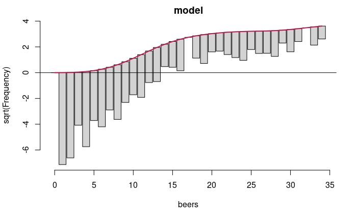

```r
countreg::rootogram(model) #package::funkcja(argument)
```

**Wnioski:** - model bardzo kiepsko dopasowuje wartości - te początkowe traktuje tak, jakby w ogóle nie istniały. Pod koniec też się wykoleja.

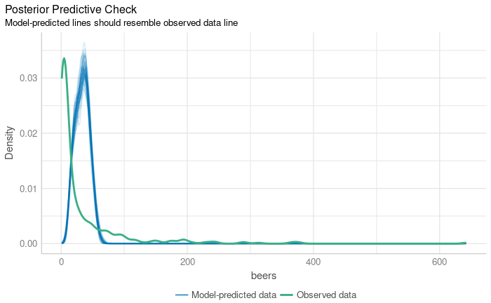

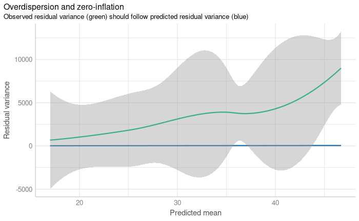

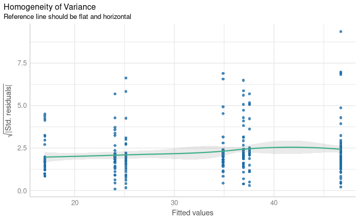

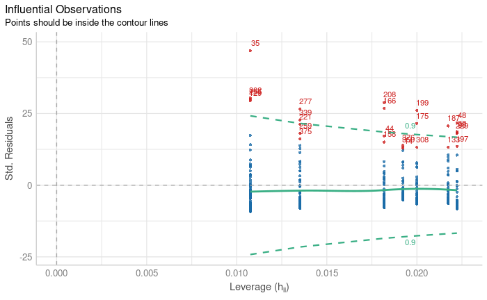

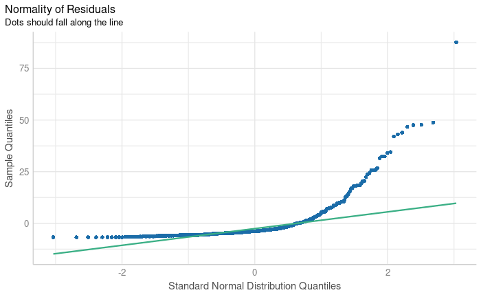

```r
performance::check_model(model, panel = F)
```

**Wnioski:** Występują problemy z homogenicznością wariancji (wykres 3). Jest dużo wartości odstających (wykres 4, czerwone punkty powinny być w ramach przerywanych zielonych linii). Reszty są asymetryczne (ostatni wykres), ale normalność reszt obchodzi nas tylko dla regresji liniowej. Można jasno stwierdzić, że model nie jest dobry.

### Dokładanie kolejnych zmiennych do modelu

Próbujemy dodać dwie zmienne (education i woj).

```r
model2 <- glm(formula = beers ~ klm+education+woj, data = aggdata, family = poisson)
summary(model2)
```

```
Call:
glm(formula = beers ~ klm + education + woj, family = poisson,
    data = aggdata)

Deviance Residuals:
    Min       1Q   Median       3Q      Max
-12.024   -6.334   -3.589    0.804   39.068

Coefficients:
                                   Estimate Std. Error z value Pr(>|z|)
(Intercept)                         2.62731    0.10633  24.708  < 2e-16 ***
klm2.under 20k                     -0.24550    0.03741  -6.563 5.27e-11 ***
klm3.20-49k                        -0.76014    0.04250 -17.884  < 2e-16 ***
klm4.50-99k                        -0.51261    0.03882 -13.205  < 2e-16 ***
klm5.100-200k                      -0.20039    0.03511  -5.708 1.15e-08 ***
klm6.200-500k                      -0.26964    0.03311  -8.145 3.81e-16 ***
klm7.500k+                          0.55654    0.03452  16.124  < 2e-16 ***
educationProfession Or Secondary    1.27402    0.10750  11.851  < 2e-16 ***
educationSecondary School Finished  1.19333    0.10216  11.681  < 2e-16 ***
educationUniversity                 1.21930    0.10218  11.933  < 2e-16 ***
wojKujawsko-Pomorskie               0.24819    0.04635   5.354 8.59e-08 ***
wojŁódzkie                         -0.72536    0.04331 -16.748  < 2e-16 ***
wojLubelskie                       -0.26166    0.05784  -4.524 6.07e-06 ***
wojLubuskie                        -1.38680    0.12696 -10.923  < 2e-16 ***
wojMałopolskie                     -1.25543    0.05173 -24.271  < 2e-16 ***
wojMazowieckie                     -0.42248    0.03247 -13.012  < 2e-16 ***
wojOpolskie                         0.33805    0.05181   6.524 6.83e-11 ***
wojPodkarpackie                     0.36462    0.04383   8.318  < 2e-16 ***
wojPodlaskie                        0.56331    0.04739  11.887  < 2e-16 ***
wojPomorskie                        0.06765    0.04230   1.599     0.11
wojŚląskie                          0.18482    0.03651   5.063 4.14e-07 ***
wojŚwiętokrzyskie                  -0.82680    0.08529  -9.694  < 2e-16 ***
wojWarmińsko-Mazurskie             -1.04023    0.06170 -16.859  < 2e-16 ***
wojWielkopolskie                   -0.84895    0.05156 -16.464  < 2e-16 ***
wojZachodniopomorskie              -0.93898    0.06691 -14.033  < 2e-16 ***
---
Signif. codes:  0 ‘***’ 0.001 ‘**’ 0.01 ‘*’ 0.05 ‘.’ 0.1 ‘ ’ 1

(Dispersion parameter for poisson family taken to be 1)

    Null deviance: 28107  on 414  degrees of freedom
Residual deviance: 24105  on 390  degrees of freedom
AIC: 25895

Number of Fisher Scoring iterations: 6
```

```r
dispersiontest(model2)
```

```
    Overdispersion test

data:  model2
z = 5.5172, p-value = 1.722e-08
alternative hypothesis: true dispersion is greater than 1
sample estimates:
dispersion
  85.72667
```

Jest odrobinę lepiej, ale wciąż średniawo.

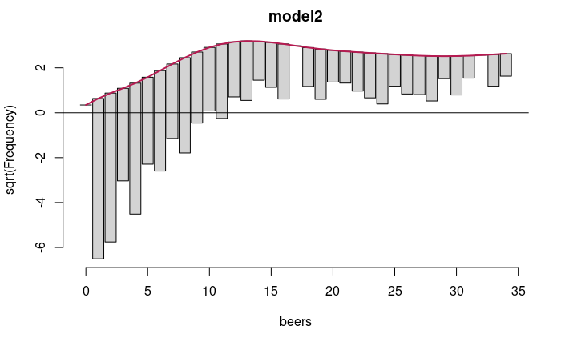

```r
countreg::rootogram(model2)
```

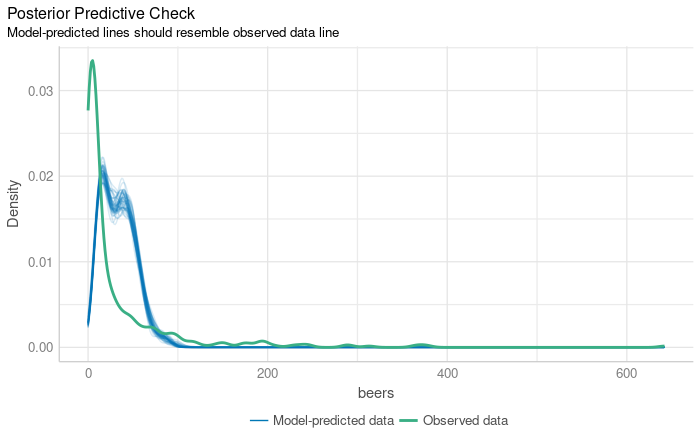

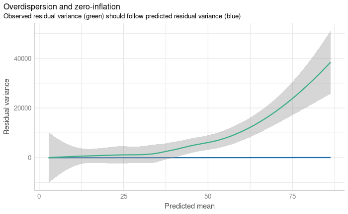

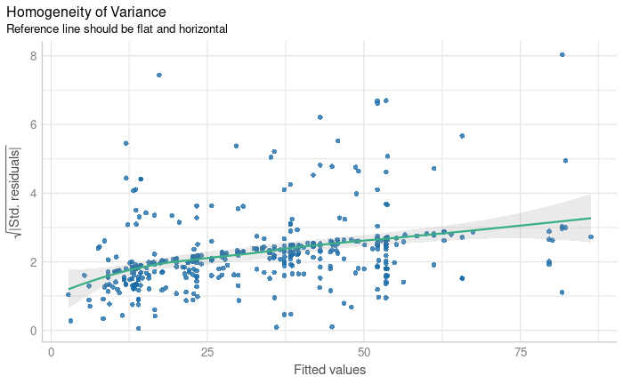

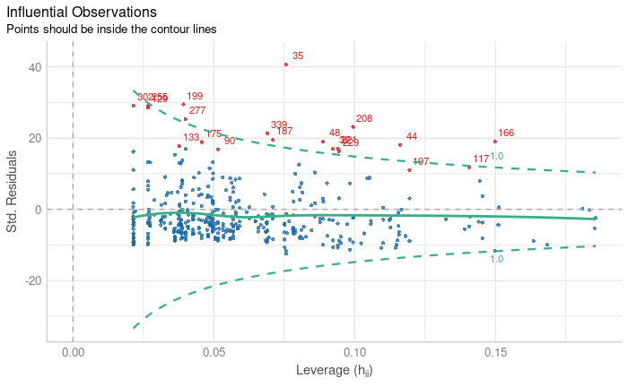

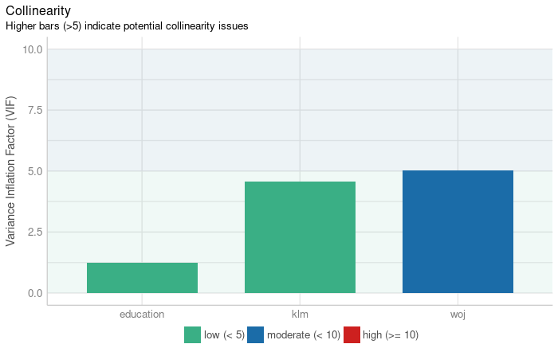

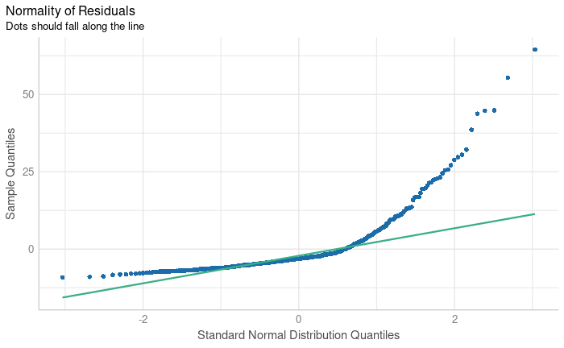

```r
performance::check_model(model2, panel = F)
```

```r
model3 <- glm(formula = beers ~ klm + woj + education, data = aggdata, family = poisson()) # zwykły poisson
model4 <- glm(formula = beers ~ klm + woj + education, data = aggdata, family = quasipoisson()) # quasipoisson (NB typ I)
model5 <- glm.nb(formula = beers ~ klm + woj + education, data = aggdata) # NB typ II
```

Sprawdźmy poprawność modelu opartego o rozkład NB typu II.

```r
summary(model5)
```

```
Call:
glm.nb(formula = beers ~ klm + woj + education, data = aggdata,
    init.theta = 0.5954610798, link = log)

Deviance Residuals:
    Min       1Q   Median       3Q      Max
-1.8936  -1.2651  -0.6601   0.1603   3.1706

Coefficients:
                                   Estimate Std. Error z value Pr(>|z|)
(Intercept)                          2.2720     0.5449   4.170 3.05e-05 ***
klm2.under 20k                      -0.2036     0.2615  -0.779 0.436238
klm3.20-49k                         -0.7104     0.2647  -2.683 0.007292 **
klm4.50-99k                         -0.3768     0.2717  -1.387 0.165496
klm5.100-200k                       -0.2809     0.2755  -1.020 0.307870
klm6.200-500k                       -0.2196     0.2607  -0.843 0.399448
klm7.500k+                           0.5579     0.2540   2.197 0.028055 *
wojKujawsko-Pomorskie                0.5198     0.3884   1.338 0.180808
wojŁódzkie                          -0.4144     0.3116  -1.330 0.183546
wojLubelskie                        -0.2766     0.4035  -0.686 0.492965
wojLubuskie                         -1.1427     0.5491  -2.081 0.037435 *
wojMałopolskie                      -1.1271     0.3320  -3.394 0.000688 ***
wojMazowieckie                      -0.2911     0.2743  -1.061 0.288559
wojOpolskie                          0.5502     0.4271   1.288 0.197651
wojPodkarpackie                      0.5255     0.3912   1.344 0.179090
wojPodlaskie                         0.6626     0.4486   1.477 0.139678
wojPomorskie                         0.1908     0.3343   0.571 0.568116
wojŚląskie                           0.3182     0.2900   1.097 0.272468
wojŚwiętokrzyskie                   -0.7177     0.4738  -1.515 0.129836
wojWarmińsko-Mazurskie              -0.7890     0.3431  -2.299 0.021483 *
wojWielkopolskie                    -0.5546     0.3464  -1.601 0.109412
wojZachodniopomorskie               -0.8439     0.3682  -2.292 0.021919 *
educationProfession Or Secondary     1.7008     0.5439   3.127 0.001764 **
educationSecondary School Finished   1.3476     0.4861   2.772 0.005573 **
educationUniversity                  1.4122     0.4866   2.902 0.003706 **
---
Signif. codes:  0 ‘***’ 0.001 ‘**’ 0.01 ‘*’ 0.05 ‘.’ 0.1 ‘ ’ 1

(Dispersion parameter for Negative Binomial(0.5955) family taken to be 1)

    Null deviance: 563.99  on 414  degrees of freedom
Residual deviance: 488.07  on 390  degrees of freedom
AIC: 3605.1

Number of Fisher Scoring iterations: 1

              Theta:  0.5955
          Std. Err.:  0.0365

 2 x log-likelihood:  -3553.0510
```

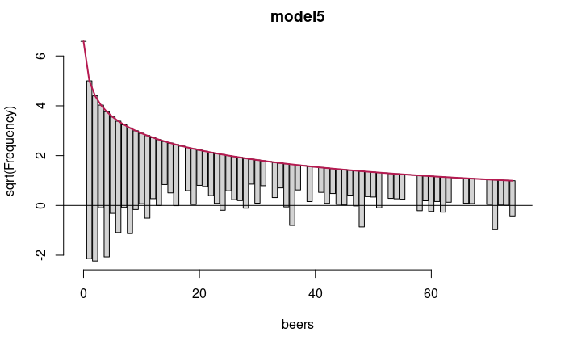

```r
rootogram(model5)
```

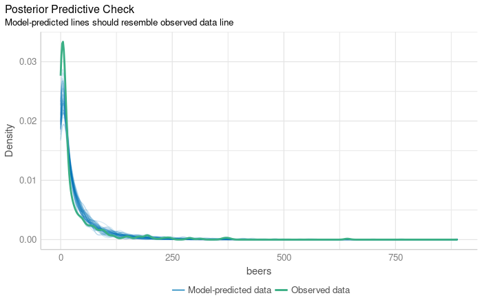

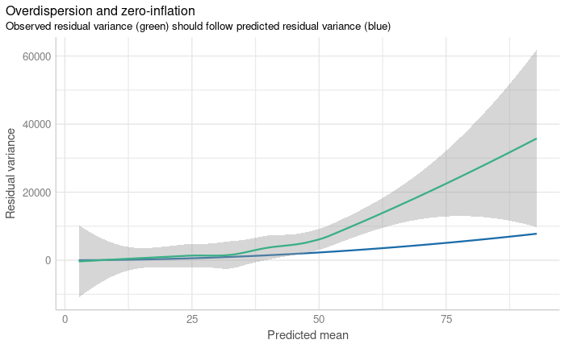

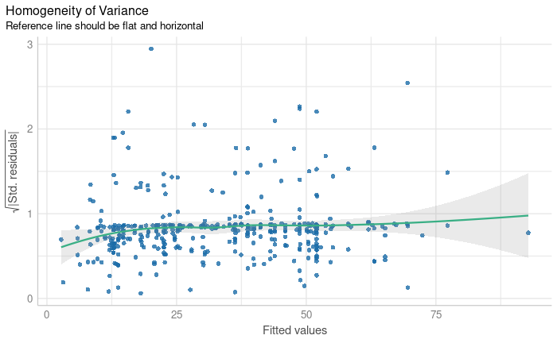

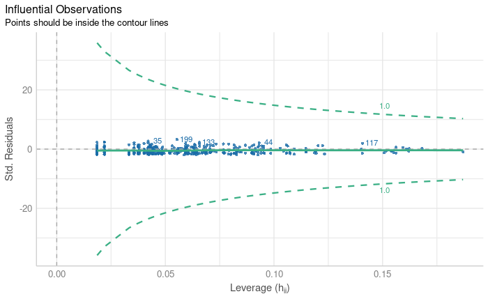

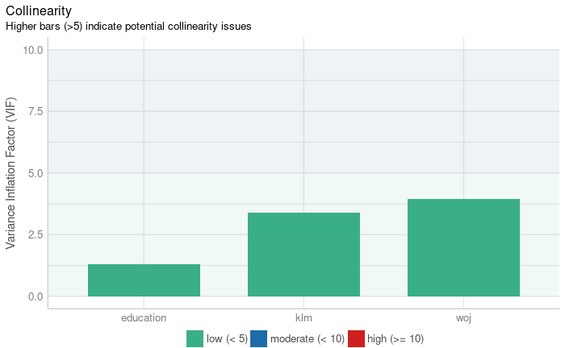

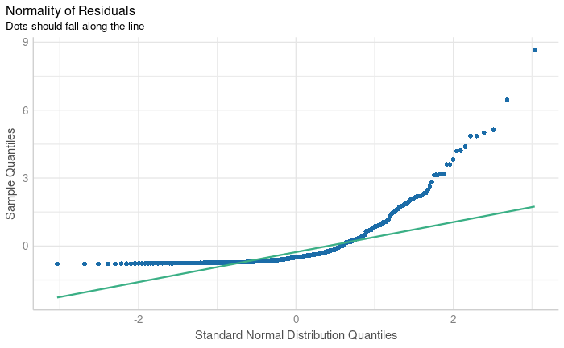

```r
check_model(model5, panel = F)
```

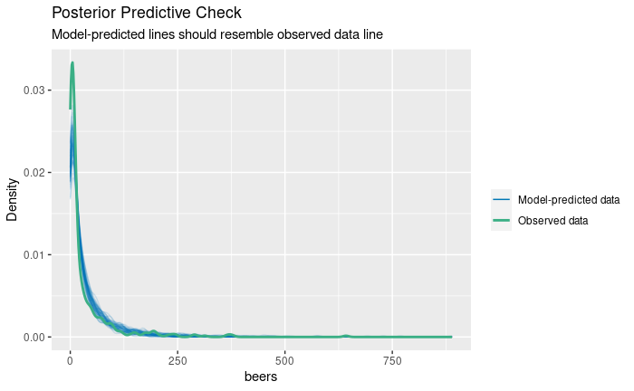

```r
check_predictions(model5) # fajny model NB
```

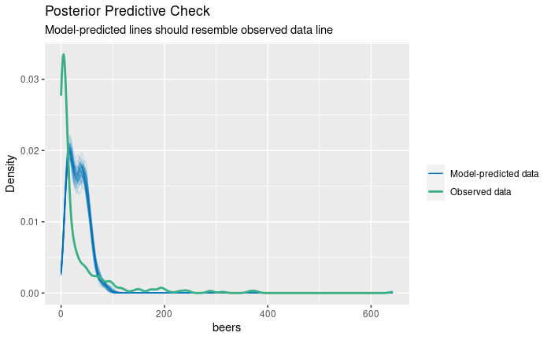

```r
check_predictions(model3) # stary, kiepski model
```

**Wnioski:** Jest git. Porównajmy też te wyniki wizualnie i kryterium informacyjnym BIC.

```r
install.packages("RColorBrewer")
```

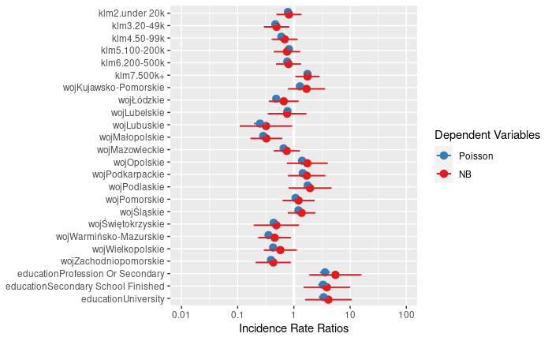

```r
plot_models(model3, model5, m.labels = c("Poisson", "NB"))
```

```r
BIC(model3, model5)
```

|  | df | BIC |
| --- | --- | --- |
| model3 | 25 | 25995.360 |
| model5 | 26 | 3709.786 |

**Wnioski:** Mniejsza wartość dla NB - jest lepszy.